# biClustering_with_funCC

```r
rm(list = ls())
```

# FunCC BiClustering

## Importing libraries

```r
#install.packages(c("patchwork", "tidyverse", "ggplot2"))

library(tidyverse)
library(ggplot2)
library(patchwork)

#install.packages(c("remotes", "biclust", "reshape", "RColorBrewer", "narray"))
#remotes::install_github("cran/FunCC")
```

## Loading data from preprocessing step

```r
data <- read.csv("data/processed/cleaned_data.csv", sep = ",")
load("data/processed/array_3d.rda")
```

## Definition of base utility function from paper

### Definition of function for computing bicluster properties

See Definition 2.1 in the FunCC paper.

In this implementation, we consider:

- I: set of stations
- J: set of day types i.e. j (WDSH,SA,SASH,SUPH,WD)

each f_ij = f_ij(time_slot).

The properties of a bicluster will be its mean, the alpha_i and the beta_j functional curves.

We decided to mimic the setting shown in Definition 2.1 thoroughly, also creating a “cube” representing the bicluster (indexed by [i,j,t]) in order to make the functions general purpose and more reusable.

```r
create_bicluster <- function(data, row_var, col_var, time_var, value_var){

  I_set = sort(unique(data[[ row_var]]))
  J_set = sort(unique(data[[col_var]]))

  card_I = length(I_set)
  card_J = length(J_set)

  n_slots = length(unique(data[[time_var]]))
  slots = seq_len(n_slots) -1

  bicluster = array(0, dim = c(card_I, card_J, n_slots),
                dimnames = list(I_set, J_set, slots))

  for (r in seq_len(nrow(data))) {
    i = match(data[[ row_var]][r], I_set)
    j = match(data[[col_var]][r], J_set)
    t = data[[time_var]][r] + 1
    bicluster[i, j, t] = data[[value_var]][r]
  }
  return(bicluster)
}
```

Also in this case we thoroughly followed the equations shown in Definition 2.1

```r
compute_bicluster_properties <- function(bicluster) {
  I_set <- dimnames(bicluster)[[1]]
  J_set <- dimnames(bicluster)[[2]]
  slots <- dimnames(bicluster)[[3]]

  card_I  <- dim(bicluster)[1]
  card_J  <- dim(bicluster)[2]
  n_slots <- dim(bicluster)[3]

  mu_IJ <- numeric(n_slots)

  for (t in seq_len(n_slots)) {
    for (i in 1:card_I) {
      for (j in 1:card_J) {
        mu_IJ[t] = mu_IJ[t] + bicluster[i, j, t]
      }
    }
    mu_IJ[t] = mu_IJ[t] / (card_I * card_J)
  }

  alpha_IJ = matrix(0, nrow = card_I, ncol = n_slots, dimnames = list(I_set, slots))

  for (t in seq_len(n_slots)) {
    for (i in 1:card_I) {
      for (j in 1:card_J) {
        alpha_IJ[i, t] = alpha_IJ[i, t] + bicluster[i, j, t]
      }
      alpha_IJ[i, t] = alpha_IJ[i, t] / card_J - mu_IJ[t]
    }
  }

  beta_IJ <- matrix(0, nrow = card_J, ncol = n_slots, dimnames = list(J_set, slots))


  for (t in seq_len(n_slots)) {
    for (j in 1:card_J) {
      for (i in 1:card_I) {
        beta_IJ[j, t] = beta_IJ[j, t] + bicluster[i, j, t]
      }
      beta_IJ[j, t] = beta_IJ[j, t] / card_I - mu_IJ[t]
    }
  }

  return(list(mu_IJ = mu_IJ, alpha_IJ = alpha_IJ, beta_IJ = beta_IJ))
}
```

### H-score function(s)

(As in Definition 2.2 of the paper)

```r
compute_h_score <- function(bicluster, mu_IJ, alpha_IJ, beta_IJ){

  slots <- dimnames(bicluster)[[3]]

  card_I  <- dim(bicluster)[1]
  card_J  <- dim(bicluster)[2]
  n_slots <- dim(bicluster)[3]

  H = 0
  for (i in 1:card_I){
    for(j in 1:card_J){

      # compute the L2 norm, that in our case is a discrete integral
      for(t in seq_len(n_slots)){
        # \bar f_ij(t) = \mu(t) + \alpha_i(t) + \beta_j(t)
        H = H+(bicluster[i,j,t]-(mu_IJ[t]+alpha_IJ[i,t]+beta_IJ[j,t]))^2
      }
    }
  }
  H = H/(card_I*card_J)
  return(H)
}
```

#### Compute residual matrix, get scores

See page 8 of the paper

```r
compute_residual_scores <- function(bicluster, mu_IJ, alpha_IJ, beta_IJ){
  # Given the bicluster, computes the residuals matrix.
  # The residuals are considered as ||f_ij-\bar f_ij||_{L2}^2
  card_I = dim(bicluster)[1]
  card_J = dim(bicluster)[2]
  n_slots = dim(bicluster)[3]

  d = matrix(0, nrow = card_I, ncol = card_J, dimnames = list(dimnames(bicluster)[[1]], dimnames(bicluster)[[2]]))

  for(i in seq_len(card_I)) {
    for(j in seq_len(card_J)){
      for(t in seq_len(n_slots)){
        d[i,j]= d[i,j] +  (bicluster[i,j,t]-(mu_IJ[t]+alpha_IJ[i,t]+beta_IJ[j,t]))^2
      }
    }
  }
  return(d)
}

get_scores <- function(bicluster){
  properties = compute_bicluster_properties(bicluster)
  d = compute_residual_scores(bicluster, properties$mu_IJ, properties$alpha_IJ, properties$beta_IJ)

  list(H = mean(d), row = rowMeans(d), col = colMeans(d))
}
```

# Preliminary testing on global dataset and visualizations

## Visualize the curves, splitted by type of day

```r
unique(data$day_cat)
```

```
## [1] "SA"   "SASH" "SUPH" "WD"   "WDSH"
```

- WD: Working day (outside of school holidays periods)
- WDSH: Working day during school holidays
- SA: Saturday (outside of school holidays periods)
- SASH: Saturday during school holidays
- SUPH: Sunday and bank holidays

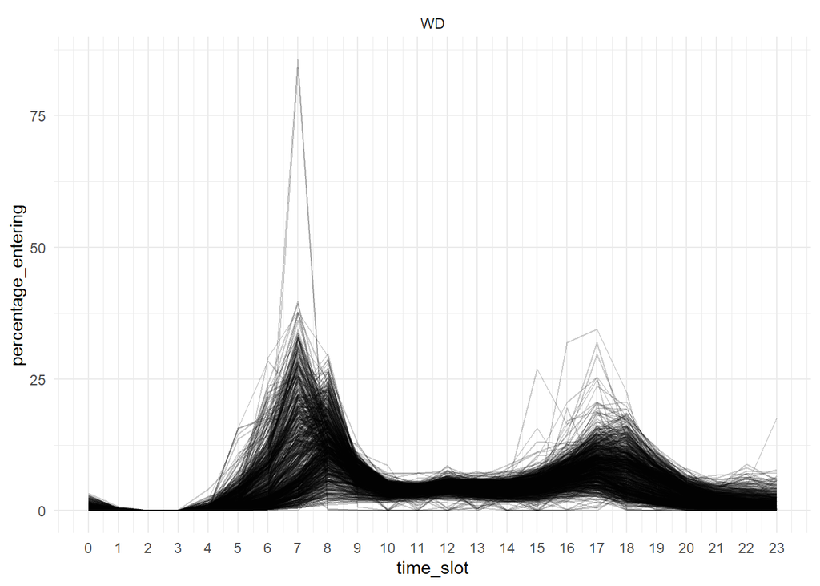

```r
plot_curves <- function(data_to_plot) {
  ggplot(data_to_plot, aes(
    x = time_slot,
    y = percentage_entering,
    group = station_id
  )) +
    geom_line(alpha = 0.2) +
    facet_wrap(~day_cat) +
    scale_x_continuous(breaks = 0:23) +
    theme_minimal()
}

data_WDSH <- data %>%
  filter(day_cat == 'WDSH')
data_SA <- data %>%
  filter(day_cat == 'SA')
data_SASH <- data %>%
  filter(day_cat == 'SASH')
data_SUPH <- data %>%
  filter(day_cat == 'SUPH')
data_WD <- data %>%
  filter(day_cat == 'WD')

plot_curves(data_WD)
```

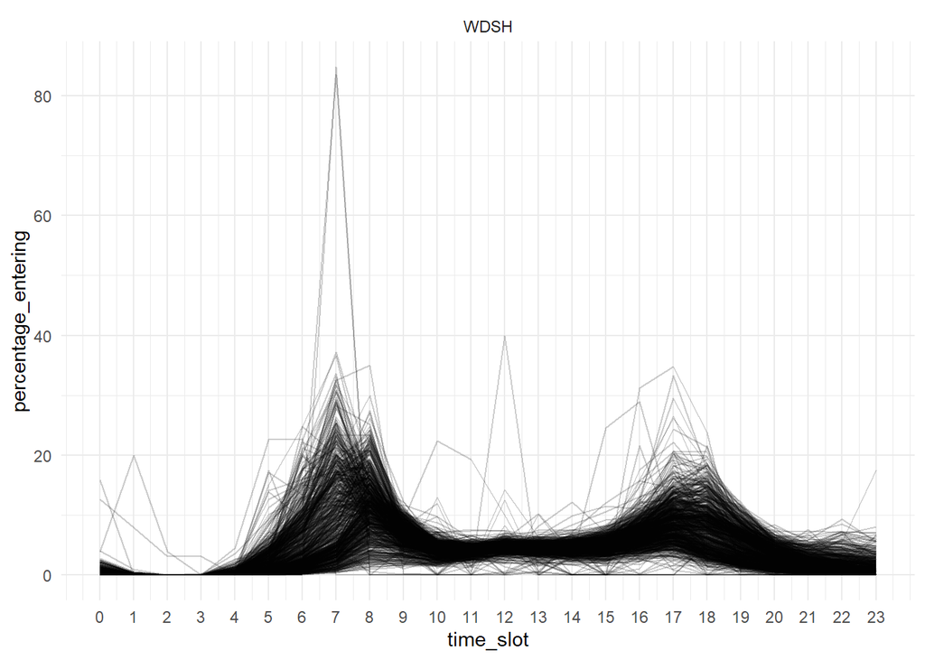

```r
plot_curves(data_WDSH)
```

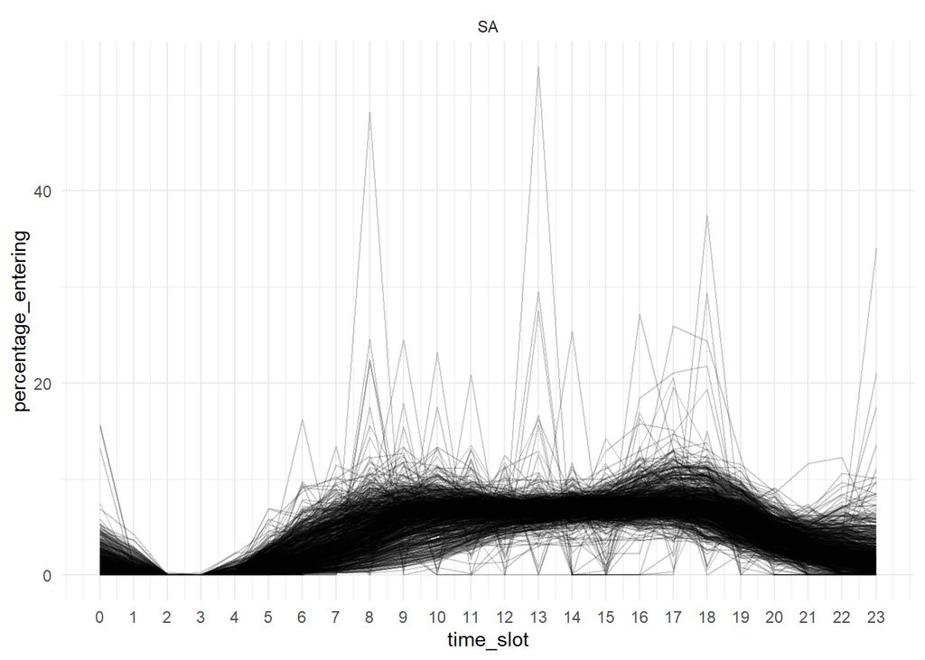

```r
plot_curves(data_SA)
```

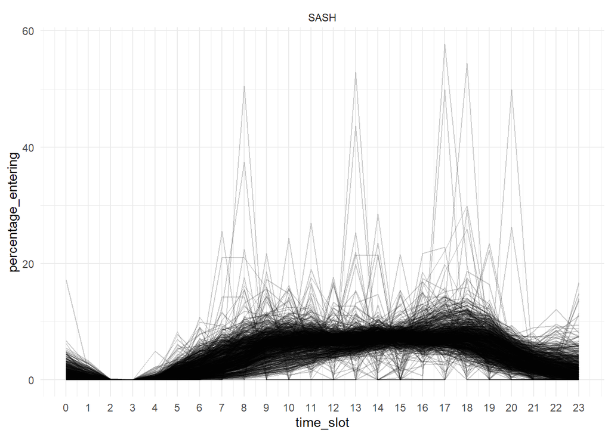

```r
plot_curves(data_SASH)
```

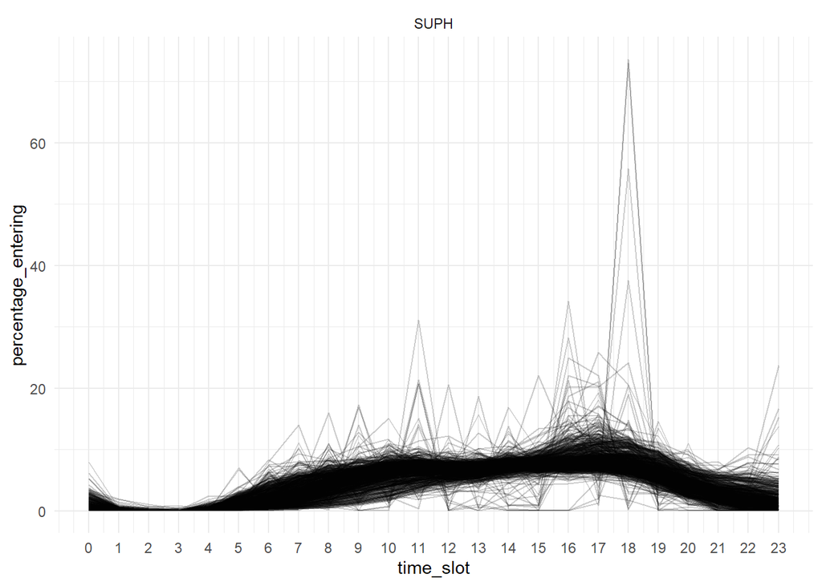

```r
plot_curves(data_SUPH)
```

## Extract mu, alpha and beta of the whole dataset (considered as a bicluster)

```r
res <- compute_bicluster_properties(array_3d)

mu_IJ    <- res$mu_IJ
alpha_IJ <- res$alpha_IJ
beta_IJ  <- res$beta_IJ
```

### Global mean mu

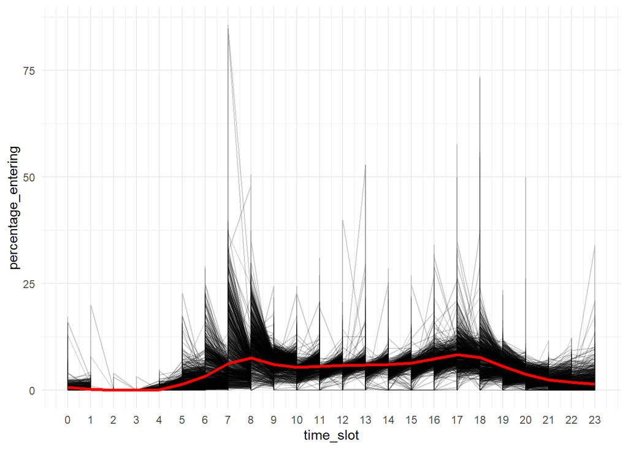

```r
ggplot(data, aes(
  x = time_slot,
  y = percentage_entering,
  group = station_id
)) +
  geom_line(alpha = 0.2) +
  geom_line(
    data = data.frame(
      time_slot = 0:23,
      mu_IJ = mu_IJ
    ),
    aes(x = time_slot, y = mu_IJ),
    color = "red",
    linewidth = 1.2,
    inherit.aes = FALSE
  ) +
  scale_x_continuous(breaks = 0:23) +
  theme_minimal()
```

### alpha: Station effect

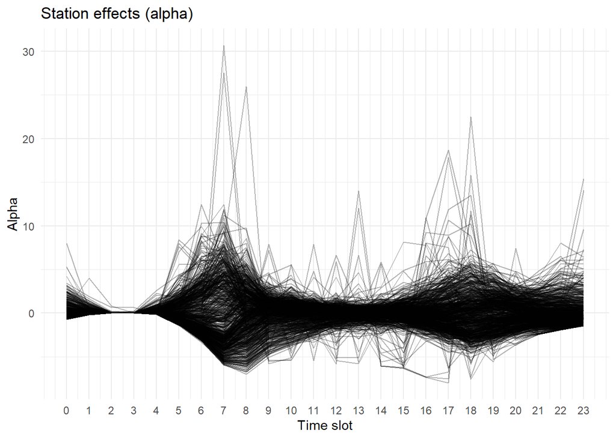

```r
alpha_df <- as.data.frame(alpha_IJ) |>
  tibble::rownames_to_column("station_id") |>
  tidyr::pivot_longer(
    cols = -station_id,
    names_to = "time_slot",
    values_to = "alpha"
  ) |>
  mutate(time_slot = as.numeric(time_slot))

ggplot(alpha_df, aes(
  x = time_slot,
  y = alpha,
  group = station_id
)) +
  geom_line(alpha = 0.3) +
  scale_x_continuous(breaks = 0:23) +
  labs(
    title = "Station effects (alpha)",
    x = "Time slot",
    y = "Alpha"
  ) +
  theme_minimal()
```

### beta: day category effects

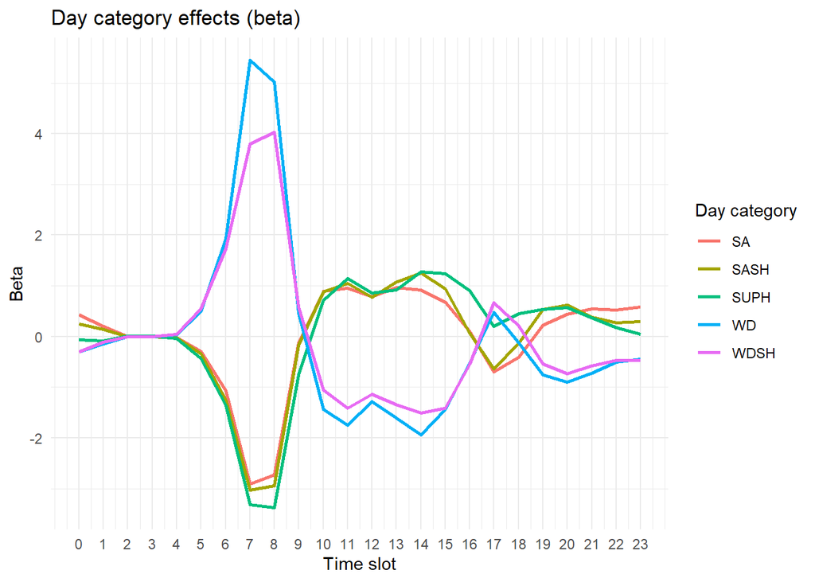

```r
beta_df <- as.data.frame(beta_IJ) |>
  tibble::rownames_to_column("day_cat") |>
  tidyr::pivot_longer(
    cols = -day_cat,
    names_to = "time_slot",
    values_to = "beta"
  ) |>
  mutate(time_slot = as.numeric(time_slot))

ggplot(beta_df, aes(
  x = time_slot,
  y = beta,
  color = day_cat,
  group = day_cat
)) +
  geom_line(linewidth = 1) +
  scale_x_continuous(breaks = 0:23) +
  labs(
    title = "Day category effects (beta)",
    x = "Time slot",
    y = "Beta",
    color = "Day category"
  ) +
  theme_minimal()
```

### Example: beta_SUPH + mu overlayed on SUPH curves

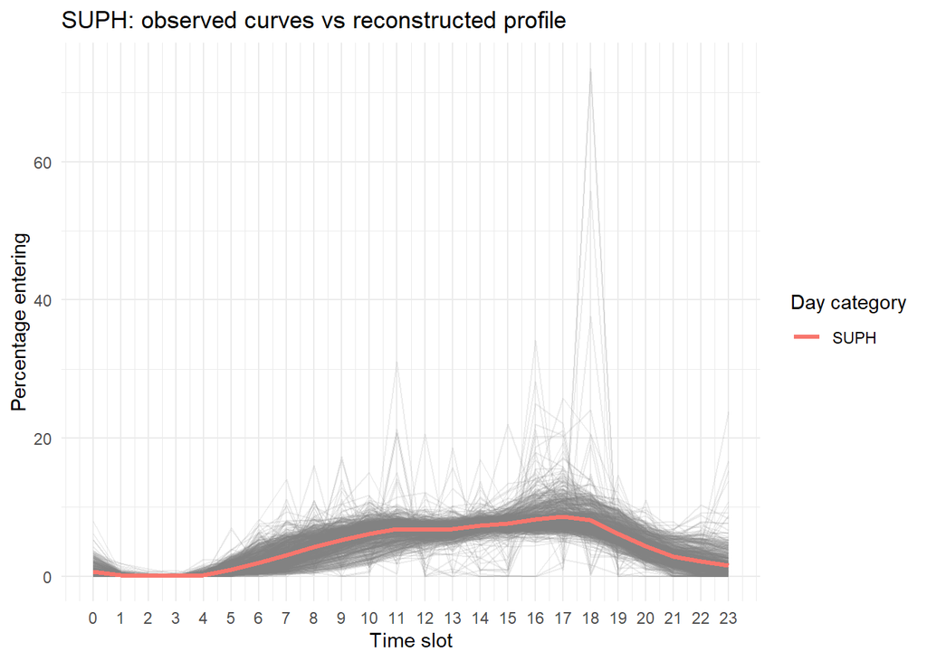

```r
beta_mu_df <- data.frame(
  time_slot = 0:23,
  profile = as.numeric(beta_IJ["SUPH", ] + mu_IJ),
  day_cat = "SUPH"
)

ggplot(data_SUPH, aes(
  x = time_slot,
  y = percentage_entering,
  group = station_id
)) +
  geom_line(alpha = 0.15, color = "grey50") +
  geom_line(
    data = beta_mu_df,
    aes(x = time_slot, y = profile, color = day_cat),
    linewidth = 1.2,
    inherit.aes = FALSE
  ) +
  scale_x_continuous(breaks = 0:23) +
  labs(
    title = "SUPH: observed curves vs reconstructed profile",
    x = "Time slot",
    y = "Percentage entering",
    color = "Day category"
  ) +
  theme_minimal()
```

# Functonal Cheng and Church algorithm (greedy) implementation

I divided the implementation by separating the single phases making them as standalone functions.

## Multiple Node Deletion Phase

From paper: This phase removes a group of rows/columns with score grater than theta*H-score.

- Every cell (i,j) has a residual: how much the curve deviates from the additive model mu(t)+alpha_i(t)+beta_j(t). We collect these residuals into a |I|x|J| matrix d, returned by compute_residual_scores().
- From d, we obtain the mean residual of the i-th row, the mean residual of the j-th column and the mean of all residuals, that is our H-score. We compute these values through the get_score() function above.
- We remove all the rows having a score grater than thetaH, then we recompute the scores and remove all the columns with score greater than theta H

### Multiple Node Deletion: Utility functions

```r
# Multiple Node Deletion Phase
delete_rows <- function(bicluster, theta){
  scores = get_scores(bicluster)
  keep = scores$row <= theta * scores$H
  return(bicluster[keep, , , drop=FALSE])
}
delete_cols <- function(bicluster, theta){
  scores = get_scores(bicluster)
  keep = scores$col <= theta * scores$H
  return(bicluster[ ,keep, , drop=FALSE])
}
```

### Multiple Node Deletion: main function

```r
multiple_node_deletion <- function(bicluster, delta, theta){
  repeat {
    n_before = sum(dim(bicluster)[1:2])

    # BULKY ROW DELETION PHASE
    if(get_scores(bicluster)$H <= theta*delta){
      break
    }
    else{
      bicluster = delete_rows(bicluster,theta)
    }
    # BULKY COLUMNS DELETION PHASE
    if(get_scores(bicluster)$H <= theta*delta){
      break
    }
    else{
      bicluster = delete_cols(bicluster,theta)
    }
    if (sum(dim(bicluster)[1:2]) == n_before) break # prevents from running forever
  }
  return(bicluster)
}
```

## Single Node Deletion Phase

From paper: this phase removes the rows/columns that reduce the H-score the most, while H-score>delta.

- We start defining a function that help us finding which row/col is effectively the worse.
  - DESIGN CHOICE: We set a minimum number of rows and a minimum number of columns. Under that, we can’t remove: would make no sense to have singletons.

### Single Node Deletion: Utility functions

```r
# Single Node Deletion Phase

find_worst_node <- function(bicluster, min_rows=2, min_cols=2){
  scores = get_scores(bicluster)

  if(dim(bicluster)[1]<min_rows || dim(bicluster)[2]<min_cols){
    return(NULL)
  }

  row_max = -Inf
  col_max = -Inf
  if(dim(bicluster)[1]>min_rows){
    row_max=max(scores$row)
  }
  if(dim(bicluster)[2]>min_cols){
    col_max = max(scores$col)
  }

  if(row_max >= col_max) {
    return(list(type = "row", index = which.max(scores$row), score=row_max))
  }
  else{
    return(list(type = "col", index = which.max(scores$col), score = col_max))
  }
}

remove_node <- function(bicluster, node) {
  if(node$type == "row"){
    return(bicluster[-node$index, , , drop=FALSE])
  }
  else{
    return(bicluster[, -node$index, , drop=FALSE])
  }
}
```

### Single Node Deletion: main function

```r
single_node_deletion <- function(bicluster, delta, min_rows = 2, min_cols = 2){
  while (get_scores(bicluster)$H > delta) {
    node = find_worst_node(bicluster, min_rows, min_cols)
    if(is.null(node)) break

    bicluster = remove_node(bicluster,node)
  }

  return(bicluster)
}
```

## Node Addition Phase

add rows/columns that do not increase the H-score.

### Node Addition Phase: Utility functions

```r
score_new_rows <- function(full, bicluster, mu_IJ, alpha_IJ, beta_IJ){
  J_names = dimnames(bicluster)[[2]]
  cand = setdiff(dimnames(full)[[1]], dimnames(bicluster)[[1]])
  n_slots = dim(full)[3]

  scores = numeric(length(cand))
  names(scores) = cand

  for (k in seq_along(cand)) {
    i = cand[k]
    for(t in seq_len(n_slots)){
      alpha_i_t = mean(full[i, J_names, t]) - mu_IJ[t]
      for(j in J_names){
        fit = mu_IJ[t] + alpha_i_t + beta_IJ[j,t]
        scores[k] = scores[k] + (full[i,j,t]-fit)^2
      }
    }
    scores[k] = scores[k] / length(J_names)
  }
  return(scores)
}



score_new_cols <- function(full, bicluster, mu_IJ, alpha_IJ, beta_IJ){
  I_names = dimnames(bicluster)[[1]]
  cand    = setdiff(dimnames(full)[[2]], dimnames(bicluster)[[2]])
  n_slots = dim(full)[3]

  scores = numeric(length(cand))
  names(scores) = cand

  for (k in seq_along(cand)) {
    j = cand[k]
    for (t in seq_len(n_slots)) {
      beta_j_t = mean(full[I_names, j, t]) - mu_IJ[t]
      for (i in I_names) {
        fit = mu_IJ[t] + alpha_IJ[i, t] + beta_j_t
        scores[k] = scores[k] + (full[i, j, t] - fit)^2
      }
    }
    scores[k] = scores[k] / length(I_names)
  }
  return(scores)
}



add_rows <- function(full, bicluster) {
  props = compute_bicluster_properties(bicluster)
  H = get_scores(bicluster)$H
  scores = score_new_rows(full, bicluster, props$mu_IJ, props$alpha_IJ, props$beta_IJ)

  to_add = names(scores)[scores <=H]
  if (length(to_add) == 0) return(bicluster)

  rows_new = dimnames(full)[[1]] %in% c(dimnames(bicluster)[[1]], to_add)
  cols_old = dimnames(full)[[2]] %in% dimnames(bicluster)[[2]]
  return(full[rows_new, cols_old, , drop = FALSE])
}



add_cols <- function(full, bicluster) {
  props  = compute_bicluster_properties(bicluster)
  H      = get_scores(bicluster)$H
  scores = score_new_cols(full, bicluster, props$mu_IJ, props$alpha_IJ, props$beta_IJ)

  to_add = names(scores)[scores <= H]
  if (length(to_add) == 0) return(bicluster)

  rows_old = dimnames(full)[[1]] %in% dimnames(bicluster)[[1]]
  cols_new = dimnames(full)[[2]] %in% c(dimnames(bicluster)[[2]], to_add)
  return(full[rows_old, cols_new, , drop = FALSE])
}
```

### Node Addition: main function

```r
node_addition <- function(full, bicluster) {

  repeat {
    n_before = sum(dim(bicluster)[1:2])
    bicluster = add_cols(full, bicluster)
    bicluster = add_rows(full, bicluster)

    if (sum(dim(bicluster)[1:2]) == n_before) break   # nothing added
  }
  return(bicluster)
}
```

## FunCC Runner

### FunCC Utility functions

```r
bicluster_indices <- function(M, bic) {
  list(
    rows = match(dimnames(bic)[[1]], dimnames(M)[[1]]),
    cols = match(dimnames(bic)[[2]], dimnames(M)[[2]])
  )
}

mask_bicluster <- function(M, bic) {
  idx  = bicluster_indices(M, bic)
  rows = idx$rows
  cols = idx$cols
  nT   = dim(M)[3]

  rng = range(M, na.rm = TRUE)
  M[rows, cols, ] = runif(length(rows) * length(cols) * nT, rng[1], rng[2])
  M
}

assigned_matrix <- function(M, biclusters) {
  asg = matrix(FALSE, dim(M)[1], dim(M)[2],
                dimnames = list(dimnames(M)[[1]], dimnames(M)[[2]]))
  for (b in biclusters) {
    idx = bicluster_indices(M, b)
    asg[idx$rows, idx$cols] = TRUE
  }
  asg
}

get_unassigned <- function(M, biclusters) {
  asg = assigned_matrix(M, biclusters)
  which(!asg, arr.ind = TRUE)
}

is_empty_bicluster <- function(M) {
  is.null(M) || length(M) == 0 || any(dim(M) == 0)
}

refine_bicluster <- function(M, delta, theta) {
  bic = multiple_node_deletion(M, delta, theta)
  bic = single_node_deletion(bic, delta)
  bic = node_addition(M, bic)
  return(bic)
}

monitor_iteration <- function(A, biclusters, history, delta) {
  acc <- history[history$accepted, ]

  p_h <- ggplot() +
    geom_hline(yintercept = delta, linetype = "dashed", colour = "grey40") +
    geom_line(data = acc, aes(iter, mean_h, colour = "Cumulative mean H")) +
    geom_point(data = acc, aes(iter, mean_h, colour = "Cumulative mean H")) +
    geom_point(data = history, aes(iter, h, colour = "Single bicluster H",
                                       shape = accepted)) +
    scale_shape_manual(values = c(`TRUE` = 16, `FALSE` = 4), name = "Accepted") +
    labs(x = "Iteration", y = "H-score", colour = NULL,
         title = paste("Iteration", max(history$iter),
                       "- accepted biclusters:", nrow(acc)),
         subtitle = "Dashed line = delta") +
    theme_minimal() +
    theme(legend.position = "bottom")

  if (length(biclusters) == 0) return(p_h)

  p_bic <- plot_biclusters_overview(A, biclusters, show_unassigned = TRUE)
  p_bic / p_h + plot_layout(heights = c(2, 1))
}
```

### Plot Bicluster Overview function

```r
plot_biclusters_overview <- function(M, biclusters, ncol_facets = 3,
                                     show_unassigned = TRUE,
                                     max_unassigned_curves = 300) {
  K <- length(biclusters)
  pal <- if (K <= 9) RColorBrewer::brewer.pal(max(K, 3), "Set1")[1:K] else
    grDevices::hcl.colors(K, "Dark 3")
  names(pal) <- seq_len(K)
  grey_col <- "grey50"

  lab <- matrix(0L, dim(M)[1], dim(M)[2],
                dimnames = list(dimnames(M)[[1]], dimnames(M)[[2]]))
  for (k in seq_len(K)) {
    idx <- bicluster_indices(M, biclusters[[k]])
    lab[idx$rows, idx$cols] <- k
  }
  asg <- lab > 0

  first_nz <- function(v) { v <- v[v > 0]; if (length(v)) min(v) else K + 1 }
  r_ord <- order(apply(lab, 1, first_nz))
  c_ord <- order(apply(lab, 2, first_nz))
  lab_o <- lab[r_ord, c_ord, drop = FALSE]

  map_df <- expand.grid(row = rownames(lab_o), col = colnames(lab_o),
                        stringsAsFactors = FALSE)
  map_df$k    <- as.vector(lab_o)
  map_df$row  <- factor(map_df$row, levels = rev(rownames(lab_o)))
  map_df$col  <- factor(map_df$col, levels = colnames(lab_o))
  map_df$fill <- ifelse(map_df$k == 0, "Unassigned", as.character(map_df$k))

  p_map <- ggplot(map_df, aes(col, row, fill = fill)) +
    geom_tile() +
    scale_fill_manual(values = c(pal, Unassigned = grey_col), guide = "none") +
    labs(x = NULL, y = NULL) +
    theme_minimal() +
    theme(axis.text = element_blank(), panel.grid = element_blank())

  to_df <- function(arr, label, colour_id) {
    df <- as.data.frame.table(arr, responseName = "value", stringsAsFactors = FALSE)
    names(df)[1:3] <- c("row", "col", "time")
    df$time  <- as.numeric(df$time)
    df$time  <- df$time / max(df$time)
    df$curve <- paste(label, df$row, df$col, sep = "_")
    df$panel <- label
    df$id    <- colour_id
    df
  }

  curves <- do.call(rbind, lapply(seq_len(K), function(k)
    to_df(biclusters[[k]], paste("Bi-cluster", k), as.character(k))))

  panel_levels <- paste("Bi-cluster", seq_len(K))

  if (show_unassigned && any(!asg)) {
    un <- which(!asg, arr.ind = TRUE)
    if (nrow(un) > max_unassigned_curves)
      un <- un[sample(nrow(un), max_unassigned_curves), , drop = FALSE]
    un_df <- do.call(rbind, lapply(seq_len(nrow(un)), function(r) {
      v <- M[un[r, 1], un[r, 2], ]
      data.frame(row = dimnames(M)[[1]][un[r, 1]],
                 col = dimnames(M)[[2]][un[r, 2]],
                 time = as.numeric(dimnames(M)[[3]]) / max(as.numeric(dimnames(M)[[3]])),
                 value = as.numeric(v),
                 curve = paste("Unassigned", un[r, 1], un[r, 2], sep = "_"),
                 panel = "Unassigned", id = "Unassigned")
    }))
    curves <- rbind(curves, un_df)
    panel_levels <- c(panel_levels, "Unassigned")
  }

  curves$panel <- factor(curves$panel, levels = panel_levels)

  p_curves <- ggplot(curves, aes(time, value, group = curve, colour = id)) +
    geom_line(aes(alpha = id == "Unassigned"), linewidth = 0.4) +
    scale_alpha_manual(values = c(`TRUE` = 0.15, `FALSE` = 0.7), guide = "none") +
    facet_wrap(~ panel, ncol = ncol_facets) +
    scale_colour_manual(values = c(pal, Unassigned = grey_col), guide = "none") +
    labs(x = NULL, y = NULL) +
    theme_gray() +
    theme(strip.text = element_text(size = 9))

  p_map + p_curves + plot_layout(widths = c(1, 1.6))
}
```

### Complete algorithm

```r
run_funCC <- function(A, delta, theta, maxIter,
                      min_rows = 2, min_cols = 2, max_fails = 5,
                      monitor = TRUE, plot_every = 1) {

  biclusters = list()
  M = A
  iter = 0
  fails = 0
  history = data.frame(iter = integer(), accepted = logical(),
                        n_rows = integer(), n_cols = integer(),
                        h = numeric(), mean_h = numeric())

  while (iter < maxIter && !is_empty_bicluster(M) && fails < max_fails) {
    iter = iter + 1

    bic = refine_bicluster(M, delta, theta)
    if (is_empty_bicluster(bic)) break

    props = compute_bicluster_properties(bic)
    h = compute_h_score(bic, props$mu_IJ, props$alpha_IJ, props$beta_IJ)
    ok = dim(bic)[1] >= min_rows && dim(bic)[2] >= min_cols && h <= delta

    if (ok) {
      biclusters[[length(biclusters) + 1]] = bic
      fails = 0
    } else {
      fails = fails + 1
    }
    M = mask_bicluster(M, bic)

    prev_h = history$h[history$accepted]
    mean_h = if (ok) mean(c(prev_h, h)) else
      if (length(prev_h)) mean(prev_h) else NA_real_

    history[nrow(history) + 1, ] = list(iter, ok, dim(bic)[1], dim(bic)[2],
                                         h, mean_h)

    if (monitor && iter %% plot_every == 0) {
      print(monitor_iteration(A, biclusters, history, delta))
    }
  }

  attr(biclusters, "history") = history
  biclusters
}
```

# Testing and other plotting functions

```
## `geom_line()`: Each group consists of only one observation.
## ℹ Do you need to adjust the group aesthetic?
```

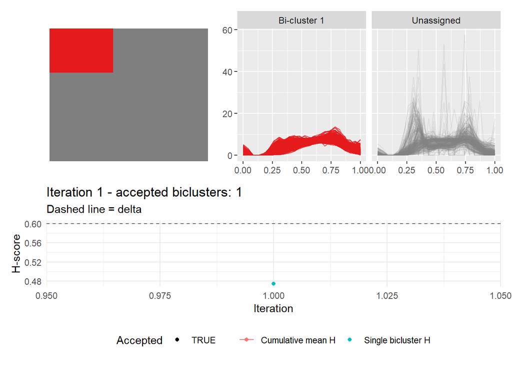

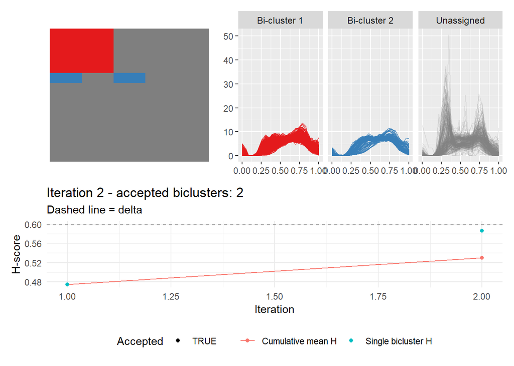

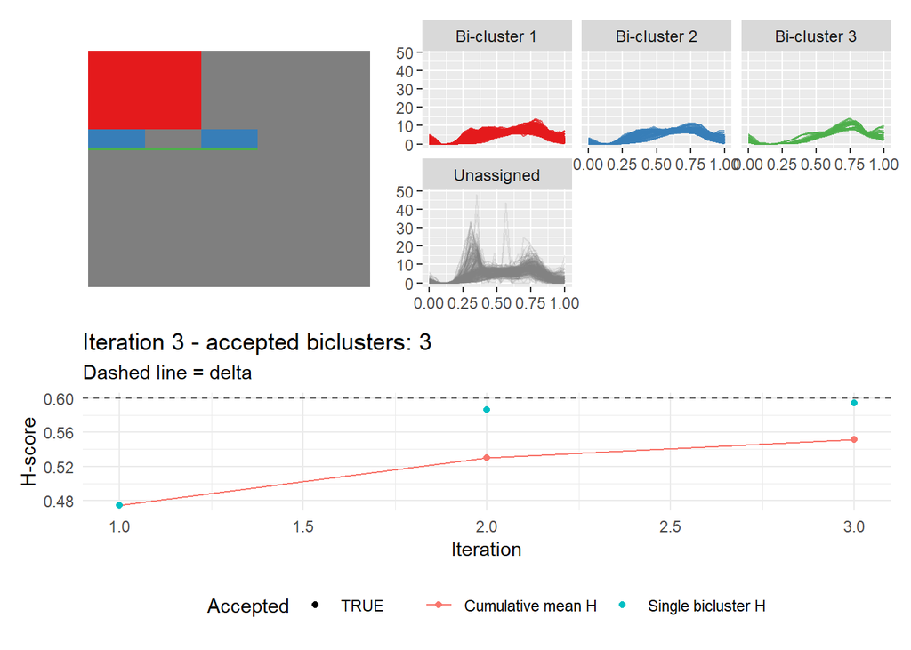

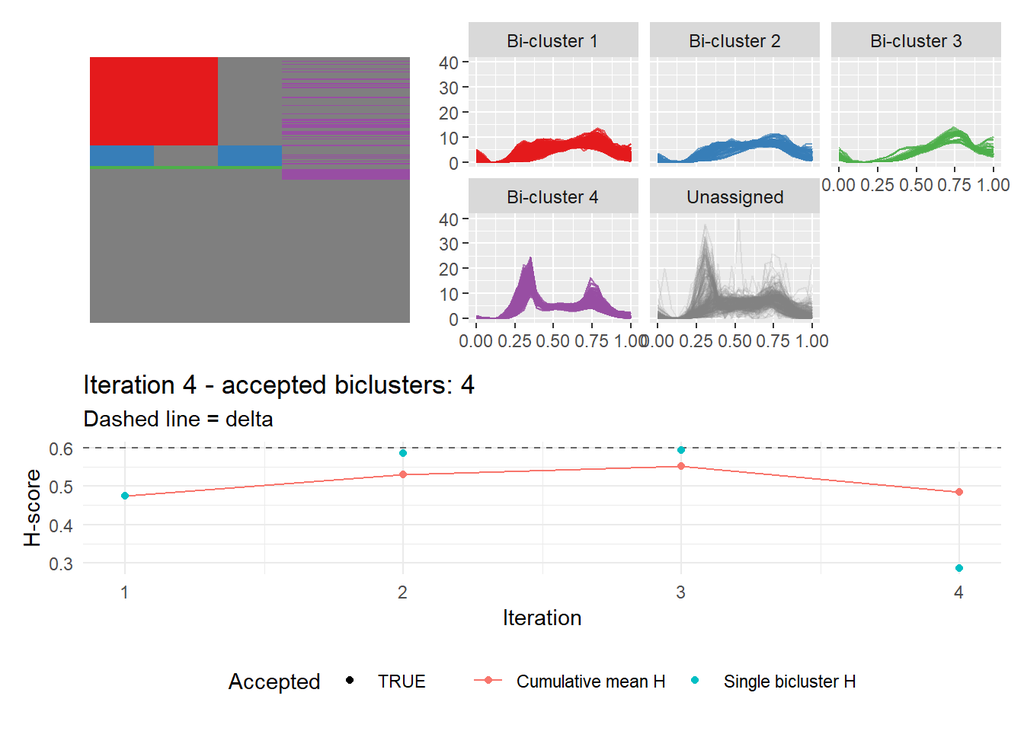

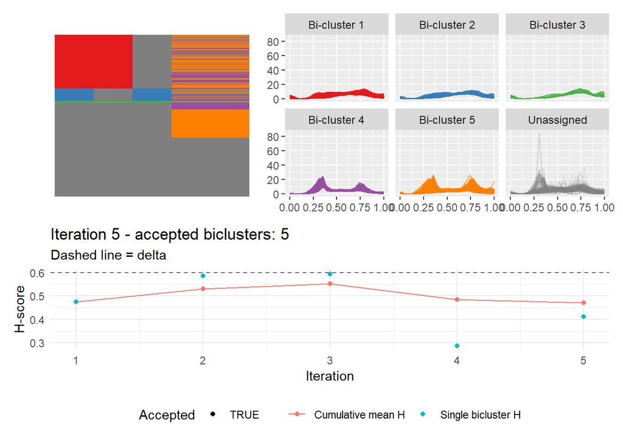

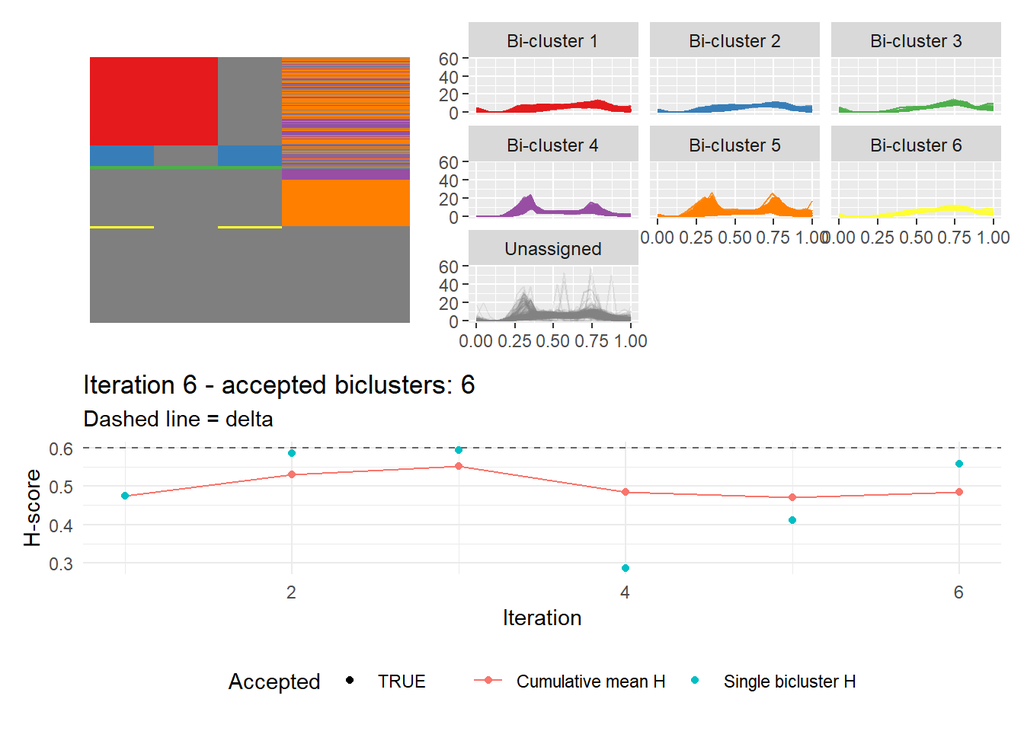

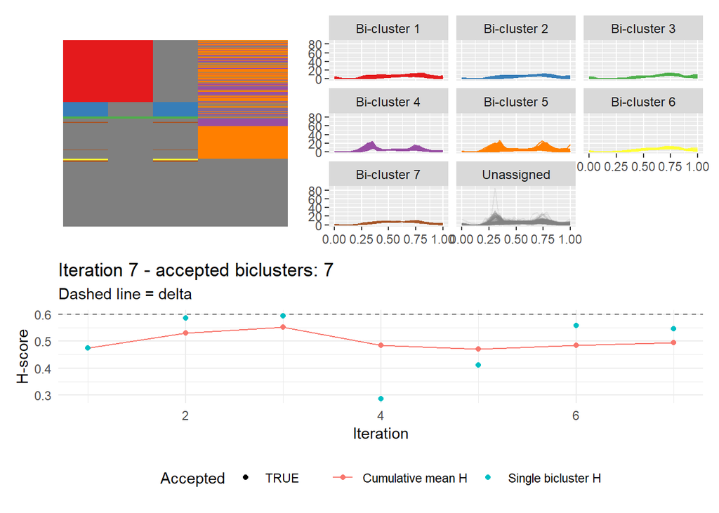

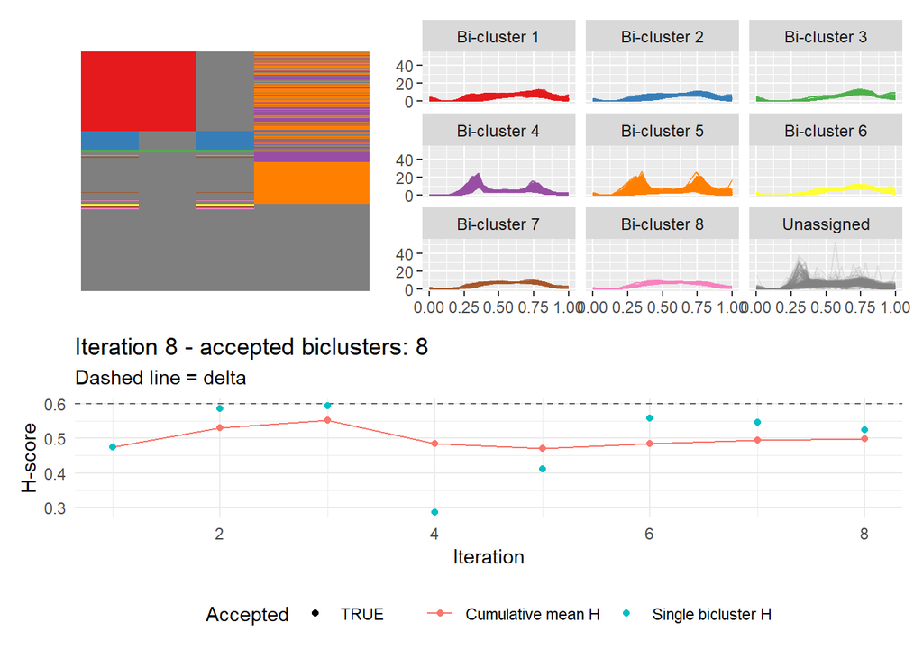

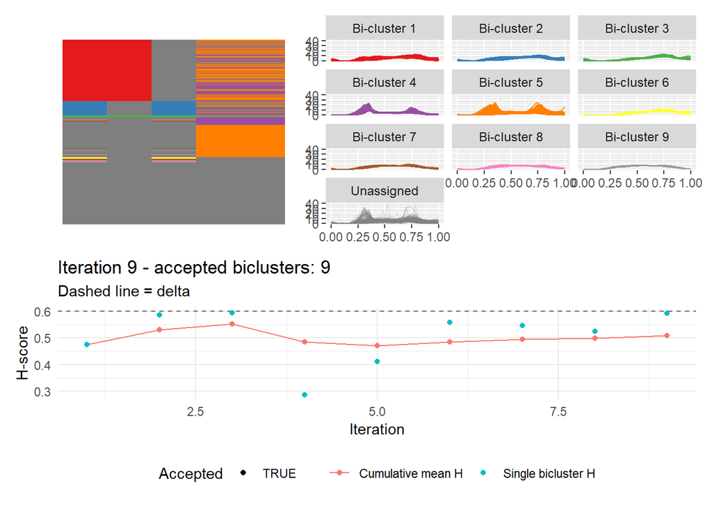

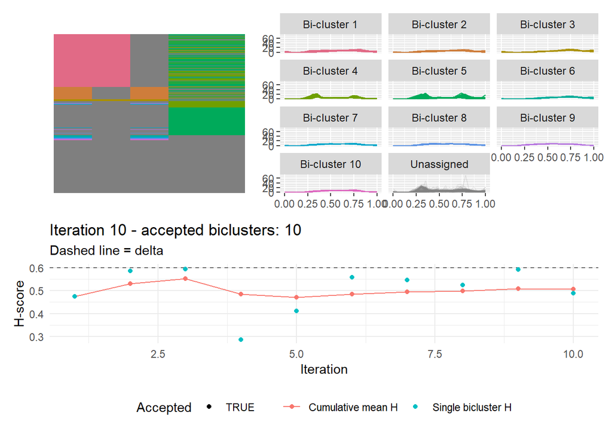

```r
res <- run_funCC(array_3d, delta = 0.6, theta = 1.2,
                 maxIter = 10, plot_every = 1)
```

```r
attr(res, "history")
```

```
##    iter accepted n_rows n_cols         h    mean_h
## 1     1     TRUE    253      2 0.4742912 0.4742912
## 2     2     TRUE     59      2 0.5862594 0.5302753
## 3     3     TRUE     10      3 0.5938798 0.5514768
## 4     4     TRUE    105      2 0.2859518 0.4850955
## 5     5     TRUE    288      2 0.4114734 0.4703711
## 6     6     TRUE     15      2 0.5583898 0.4850409
## 7     7     TRUE     11      2 0.5469252 0.4938815
## 8     8     TRUE     12      2 0.5249889 0.4977699
## 9     9     TRUE      7      2 0.5910949 0.5081394
## 10   10     TRUE      6      2 0.4880486 0.5061303
```

### Final Overview

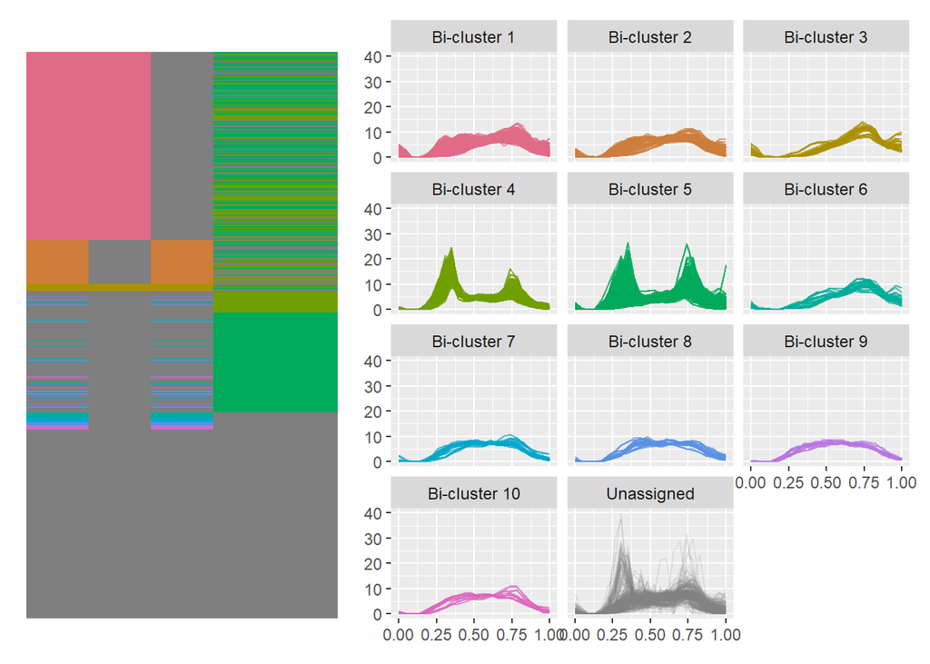

```r
set.seed(1)
plot_biclusters_overview(array_3d, res)
```

### Detailed Overview

```r
plot_bicluster_curves <- function(bic, main = "") {
  I  <- dimnames(bic)[[1]]
  J  <- dimnames(bic)[[2]]
  tt <- as.numeric(dimnames(bic)[[3]])

  op <- par(mfrow = c(1, length(J)), mar = c(4, 4, 2, 1))
  on.exit(par(op))

  ylim <- range(bic, na.rm = TRUE)
  cols <- rainbow(length(I))

  for (j in seq_along(J)) {
    Y <- t(matrix(bic[, j, ], nrow = length(I)))
    matplot(tt, Y, type = "l", lty = 1, col = cols, ylim = ylim,
            xlab = "Time", ylab = "Value",
            main = paste(main, "- column", J[j]))
  }
  legend("topright", legend = I, col = cols, lty = 1, cex = 0.6, bty = "n")
}

plot_bicluster_map <- function(M, biclusters) {
  lab <- matrix(0, dim(M)[1], dim(M)[2])
  for (k in seq_along(biclusters)) {
    idx <- bicluster_indices(M, biclusters[[k]])
    lab[idx$rows, idx$cols] <- k
  }
  pal <- c("grey95", rainbow(length(biclusters)))
  image(x = seq_len(ncol(lab)), y = seq_len(nrow(lab)), z = t(lab),
        col = pal, zlim = c(0, length(biclusters)),
        xlab = "Columns (J)", ylab = "Rows (I)", main = "Biclusters in the dataset")
  legend("topright", legend = paste("B", seq_along(biclusters)),
         fill = pal[-1], bty = "n", cex = 0.8)
}
```

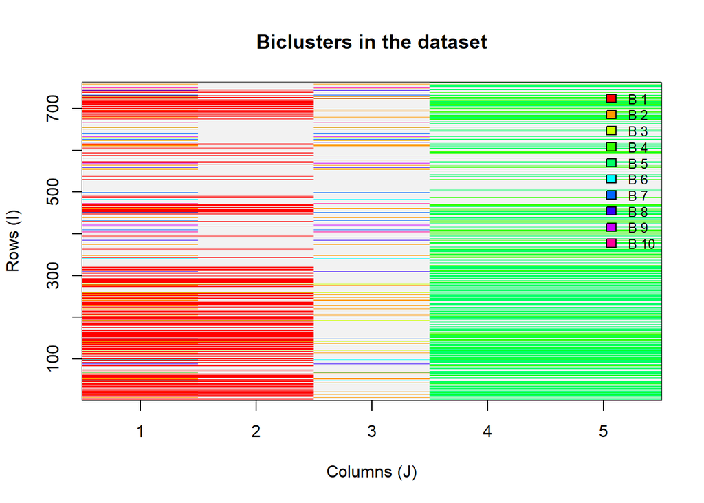

```r
plot_bicluster_map(array_3d, res)
```

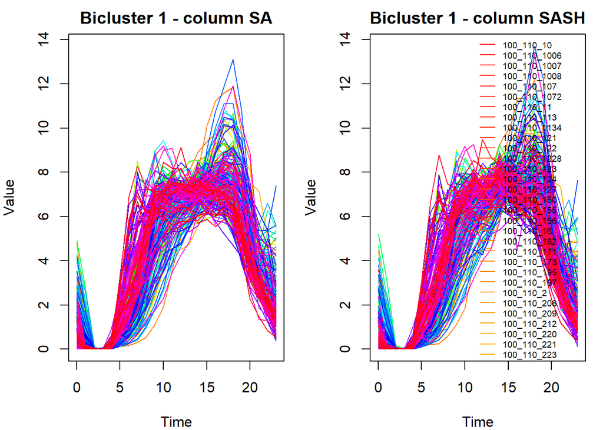

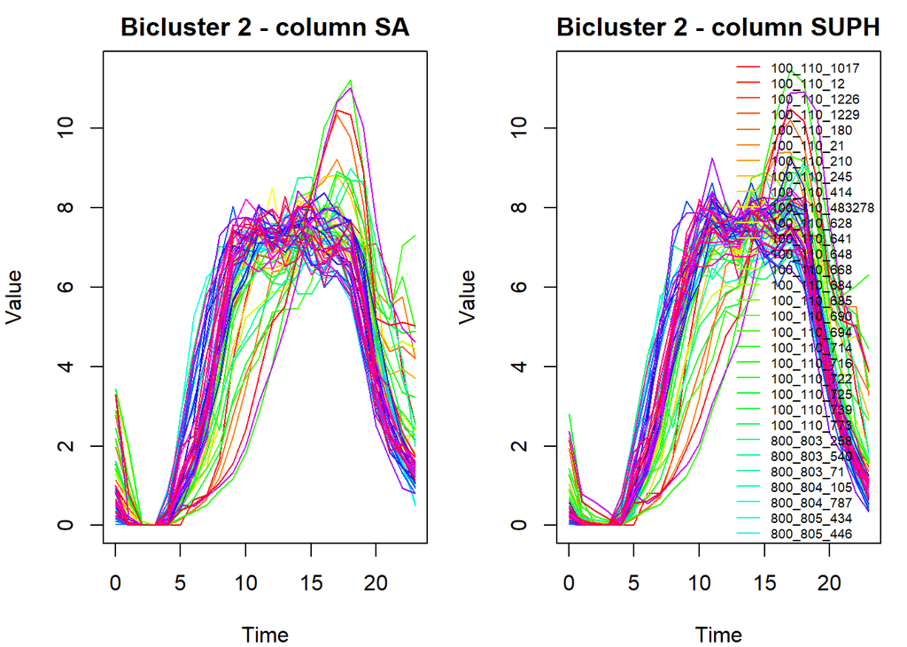

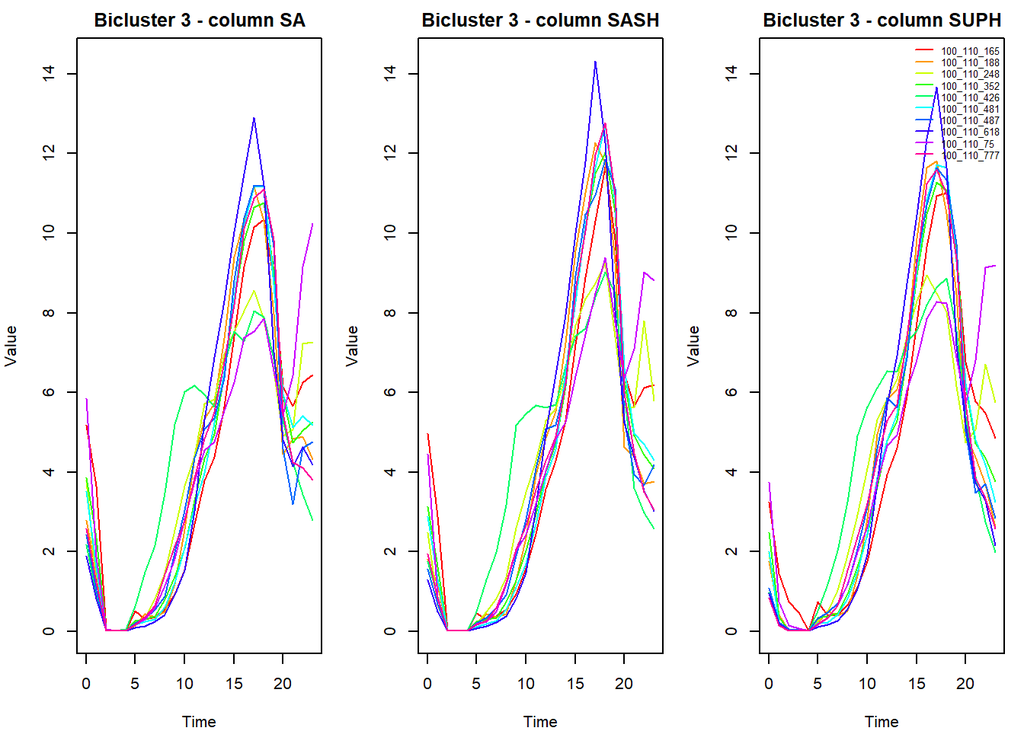

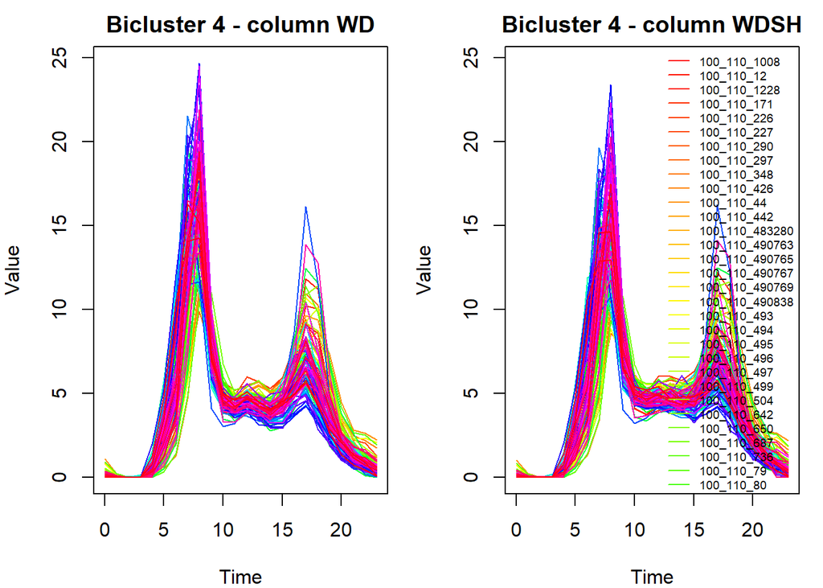

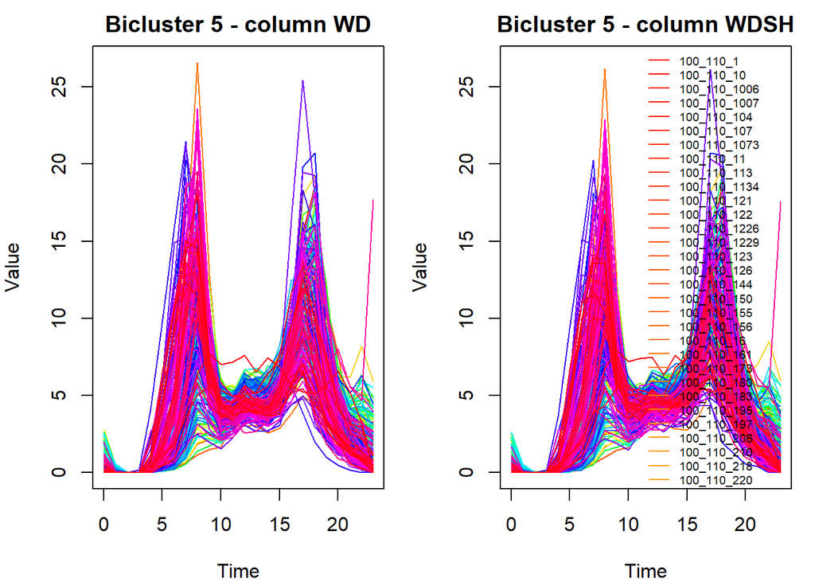

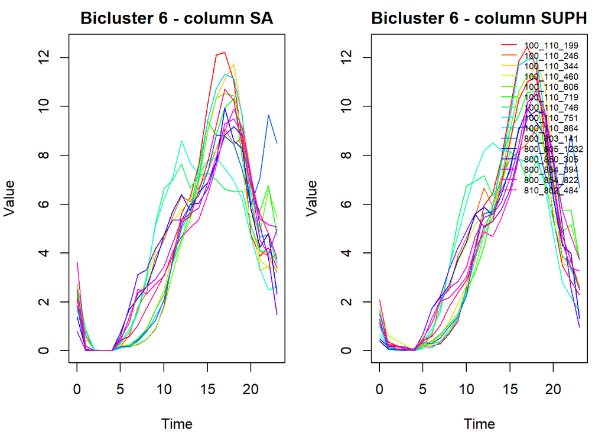

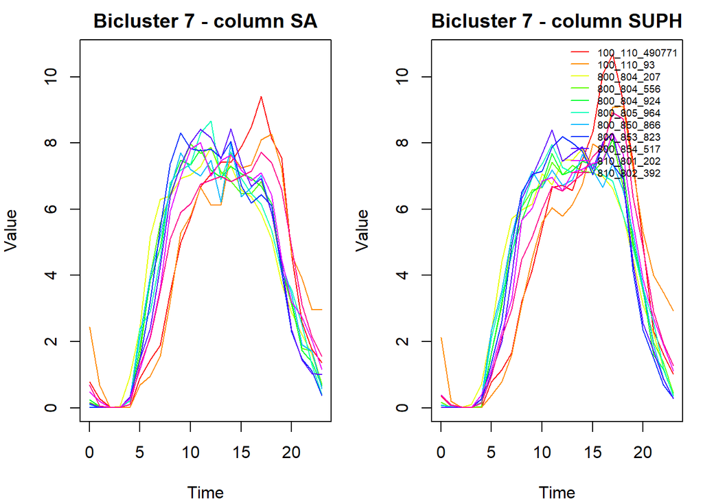

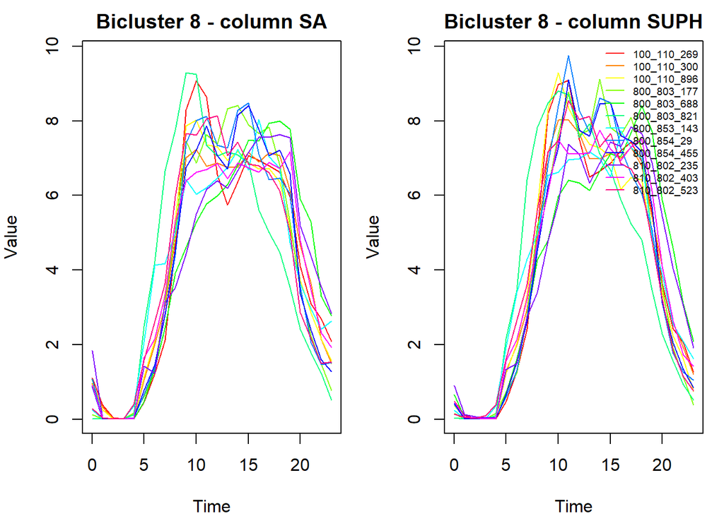

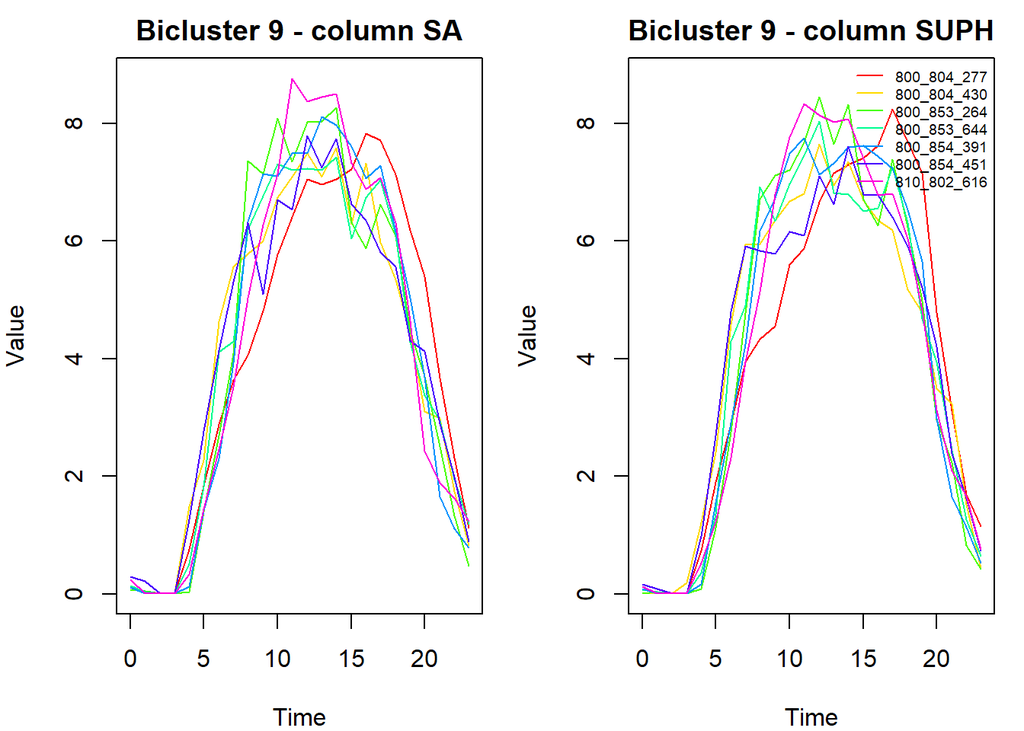

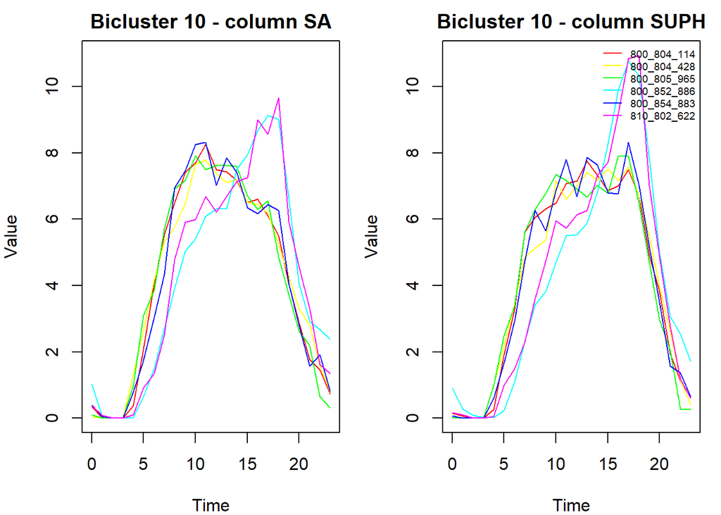

```r
for (k in seq_along(res)) {
  plot_bicluster_curves(res[[k]], main = paste("Bicluster", k))
}
```

### Number of elements per bicluster

```r
summary_bic <- data.frame(
  bicluster = seq_along(res),
  n_rows   = sapply(res, function(b) dim(b)[1]),
  n_cols = sapply(res, function(b) dim(b)[2]),
  n_t   = sapply(res, function(b) dim(b)[3])
)

print(summary_bic)
```

```
##    bicluster n_rows n_cols n_t
## 1          1    253      2  24
## 2          2     59      2  24
## 3          3     10      3  24
## 4          4    105      2  24
## 5          5    288      2  24
## 6          6     15      2  24
## 7          7     11      2  24
## 8          8     12      2  24
## 9          9      7      2  24
## 10        10      6      2  24
```

```r
dim(array_3d)
```

```
## [1] 763   5  24
```

## Export of results

```r
get_unassigned_bicluster <- function(M, biclusters) {
  asg <- assigned_matrix(M, biclusters)
  nT  <- dim(M)[3]

  U <- M
  U[rep(as.vector(asg), times = nT)] <- NA

  un <- which(!asg, arr.ind = TRUE)
  long <- NULL
  if (nrow(un) > 0) {
    n  <- nrow(un)
    ti <- rep(seq_len(nT), times = n)
    long <- data.frame(
      station = dimnames(M)[[1]][rep(un[, 1], each = nT)],
      column  = dimnames(M)[[2]][rep(un[, 2], each = nT)],
      time    = dimnames(M)[[3]][ti],
      value   = M[cbind(rep(un[, 1], each = nT), rep(un[, 2], each = nT), ti)],
      stringsAsFactors = FALSE
    )
  }
  list(array = U, long = long, n_cells = nrow(un))
}

u <- get_unassigned_bicluster(array_3d, res)

res_export <- c(res, list(unassigned = u$array))
names(res_export) <- c(paste0("bicluster_", seq_along(res)), "unassigned")
attr(res_export, "history") <- attr(res, "history")

saveRDS(res_export, "data/clustering/biclusters.rds")
```

### How to load

Use the following commands:

```r
res_export <- readRDS("data/clustering/biclusters.rds")

unassigned <- res_export[["unassigned"]] # this takes the unassigned elements
biclusters <- res_export[names(res_export) != "unassigned"] # this takes the actual biclusters
attr(res, "history") <- attr(res_export, "history") # this is for the FunCC algorithm iterations history (if needed)
```

### How to use

```r
length(biclusters)                    # number of accepted biclusters
```

```
## [1] 10
```

```r
b <- biclusters[[1]]                  # first bicluster
dim(b)                         # |I| x |J| x T
```

```
## [1] 253   2  24
```

```r
dimnames(b)[[1]]               # rows (stations)
```

```
##   [1] "100_110_10"       "100_110_1006"     "100_110_1007"
##   [4] "100_110_1008"     "100_110_107"      "100_110_1072"
##   [7] "100_110_11"       "100_110_113"      "100_110_1134"
##  [10] "100_110_121"      "100_110_122"      "100_110_1228"
##  [13] "100_110_123"      "100_110_124"      "100_110_127"
##  [16] "100_110_150"      "100_110_155"      "100_110_156"
##  [19] "100_110_16"       "100_110_162"      "100_110_171"
##  [22] "100_110_173"      "100_110_195"      "100_110_197"
##  [25] "100_110_2"        "100_110_206"      "100_110_209"
##  [28] "100_110_212"      "100_110_220"      "100_110_221"
##  [31] "100_110_223"      "100_110_224"      "100_110_226"
##  [34] "100_110_227"      "100_110_228"      "100_110_233"
##  [37] "100_110_236"      "100_110_25"       "100_110_253"
##  [40] "100_110_27"       "100_110_279"      "100_110_282"
##  [43] "100_110_290"      "100_110_297"      "100_110_299"
```

[output cut: 70 more lines]

```r
dimnames(b)[[2]]               # columns (day_type)
```

```
## [1] "SA"   "SASH"
```

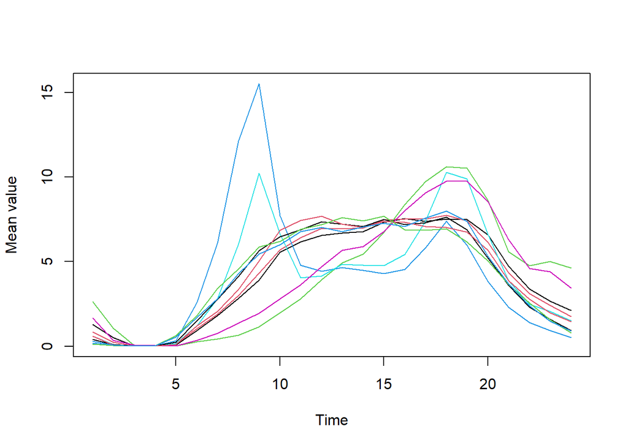

```r
# EXAMPLE: stations of each bicluster
stations <- lapply(res, function(b) dimnames(b)[[1]])

# EXAMPLE: average curve of each bicluster (T values)
mean_curves <- sapply(res, function(b) apply(b, 3, mean))   # T x K matrix
matplot(mean_curves, type = "l", lty = 1, xlab = "Time", ylab = "Mean value")
```